# DS5740: Week 1 | TSLM Script

Jaewoo Cho

# Libraries & Data

```r
# Load {fpp3}
library(fpp3)
```

```r
# Load US Consumption Expenditure
data("us_change")
```

# Time series Plots

## Plot multiple variables’ time series

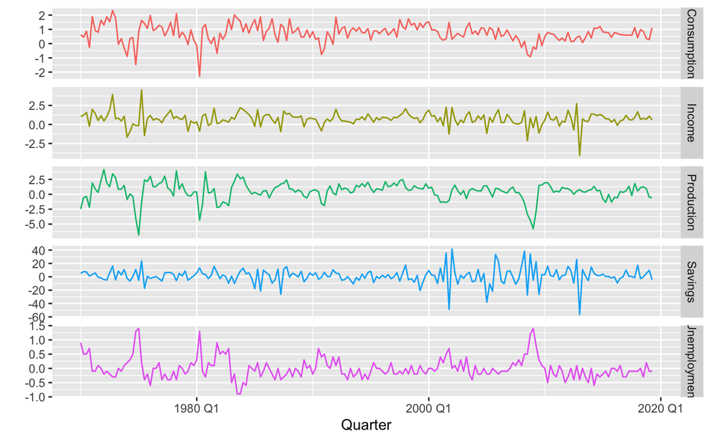

```r
# Plot multiple variables' time series
us_change %>%
  gather("Measure", "Change", Consumption, Income, Production, Savings, Unemployment) %>%
  ggplot(aes(x = Quarter, y = Change, colour = Measure)) +
  geom_line() +
  facet_grid(vars(Measure), scales = "free_y") +
  labs(y = "") +
  guides(colour="none")
```

## Plot pairwise correlations

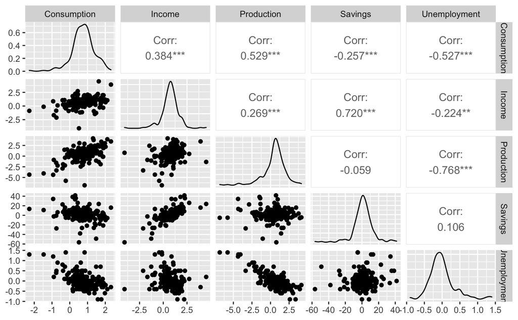

## Fit TSLM & Report fit

```r
report(fit)
```

```
Series: Consumption
Model: TSLM

Residuals:
     Min       1Q   Median       3Q      Max
-0.90555 -0.15821 -0.03608  0.13618  1.15471

Coefficients:
              Estimate Std. Error t value Pr(>|t|)
(Intercept)   0.253105   0.034470   7.343 5.71e-12 ***
Income        0.740583   0.040115  18.461  < 2e-16 ***
Production    0.047173   0.023142   2.038   0.0429 *
Unemployment -0.174685   0.095511  -1.829   0.0689 .
Savings      -0.052890   0.002924 -18.088  < 2e-16 ***
---
Signif. codes:  0 ‘***’ 0.001 ‘**’ 0.01 ‘*’ 0.05 ‘.’ 0.1 ‘ ’ 1

Residual standard error: 0.3102 on 193 degrees of freedom
Multiple R-squared: 0.7683, Adjusted R-squared: 0.7635
F-statistic:   160 on 4 and 193 DF, p-value: < 2.22e-16
```

## Details of the report(fit)

- Coefficients: For each of the predictors (Income, Production, Unemployment, and Savings), you’d see a coefficient. This coefficient represents the change in Consumption for a one-unit increase in the predictor, holding all other variables constant.
- Intercept: This value gives the expected value of Consumption when all predictors are set to zero.
- t-values and p-values: These statistics provide information about the significance of each predictor. A smaller p-value (typically less than 0.05) suggests that a predictor is statistically significant in predicting the response variable.
- R-squared: This value gives an idea of the proportion of variance in the dependent variable that’s explained by the independent variables. It ranges from 0 to 1, with higher values indicating a better fit.
- Residual standard error: This metric provides a measure of the average amount that the predictions deviate from the actual observations.
- F-statistic and its associated p-value: This checks the overall significance of the model. A significant F-statistic (small p-value) suggests that at least one of the predictors is useful in predicting the response variable.
- Remember, while statistical significance is useful, it doesn’t always translate to practical significance. Also, fitting a model is only the beginning. Checking assumptions of linear regression (like normality of residuals, homoscedasticity, etc.), as well as the potential for multicollinearity among predictors, is crucial for ensuring the validity and reliability of the model’s results.

## Explaination of the results

### Series and Model

- Series: This represents the dependent variable, which is Consumption in this case.
- Model: Specifies the type of model used, which is TSLM.

### Residuals

- This section describes the distribution of the residuals (differences between observed and predicted values):
- Min and Max: The minimum and maximum residual values.
- 1Q and 3Q: The first (25th percentile) and third quartiles (75th percentile) of the residuals.
- Median: The median residual value, which provides a central tendency measure of the residuals.

### Coefficients

- This is the core part of the output, detailing the regression coefficients and their significance:
- (Intercept): The expected value of Consumption when all predictors are zero.
- Income, Production, Unemployment, and Savings: These are the estimated coefficients for each predictor. For instance, for every one-unit increase in Income, the Consumption is expected to increase by approximately 0.740583 units, holding all other variables constant.
- Std. Error: Standard error for each coefficient.
- t value: The t-statistic value for each coefficient.
- Pr(>|t|): The p-value associated with each coefficient’s t-value.
- The asterisks and dots next to the p-values indicate their significance:
- ***: Highly significant (p-value < 0.001)
- **: Very significant (p-value < 0.01)
- *: Significant (p-value < 0.05)
- .: Marginally significant (p-value < 0.1)

### Interpretation:

- Income and Savings have the most significant impact on Consumption, given their very low p-values (< 2e-16) and relatively high t-values.
- Production has a significant impact on Consumption at the 0.05 level.
- Unemployment is marginally significant, implying that while it may have an effect on Consumption, it’s less robustly established compared to other predictors in this model.
- The adjusted R-squared suggests a good fit, with over 76% of the variation in Consumption explained by the model.

```r
# Length of time series
ts_length <- nrow(us_change)

# Remove last five years (we'll make a prediction later)
us_prediction <- us_change[
  -c((ts_length - 19):ts_length), # remove last 5 years
]

# Save last five years (we'll compare with prediction)
us_actual <- us_change[
  c((ts_length - 19):ts_length), # keeps last 5 years
]

fit_us_lm <- us_prediction %>%
  model(lm = TSLM(
    Consumption ~ Income + Production + Unemployment + Savings
  ))

# Report fit
report_fit <- report(fit_us_lm)
```

```
Series: Consumption
Model: TSLM

Residuals:
     Min       1Q   Median       3Q      Max
-0.89952 -0.16879 -0.03979  0.13944  1.14909

Coefficients:
              Estimate Std. Error t value Pr(>|t|)
(Intercept)   0.261795   0.037847   6.917 8.56e-11 ***
Income        0.737779   0.042300  17.442  < 2e-16 ***
Production    0.044788   0.026403   1.696   0.0916 .
Unemployment -0.191468   0.107811  -1.776   0.0775 .
Savings      -0.052416   0.003091 -16.960  < 2e-16 ***
---
Signif. codes:  0 ‘***’ 0.001 ‘**’ 0.01 ‘*’ 0.05 ‘.’ 0.1 ‘ ’ 1

Residual standard error: 0.3251 on 173 degrees of freedom
Multiple R-squared: 0.768,  Adjusted R-squared: 0.7627
F-statistic: 143.2 on 4 and 173 DF, p-value: < 2.22e-16
```

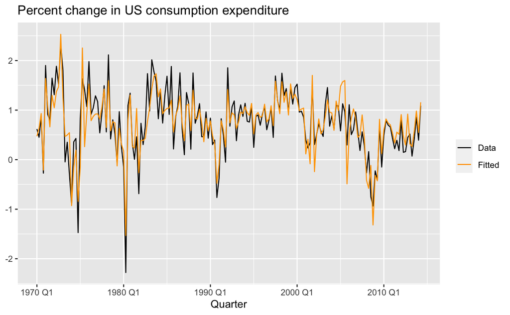

```r
# Plot model
augment(fit_us_lm) %>%
  # Plot quarter on x-axis
  ggplot(aes(x = Quarter)) +
  # Plot actual values
  geom_line(aes(y = Consumption, colour = "Data")) +
  # Plot fit values
  geom_line(aes(y = .fitted, colour = "Fitted")) +
  labs(
    # No y-axis label
    y = NULL,
    # Change title
    title = "Percent change in US consumption expenditure"
  ) +
  # Change colors
  scale_colour_manual(
    values = c(
      Data = "black", # Make data line black
      Fitted = "orange" # Make fitted line orange
    )
  ) +
  # No title for legend
  guides(colour = guide_legend(title = NULL))
```

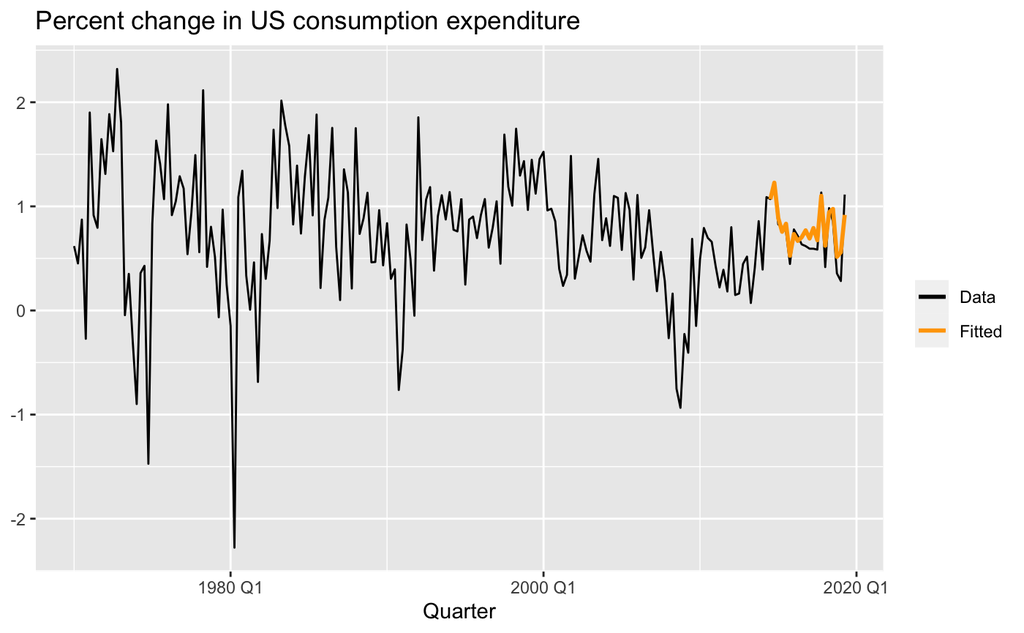

```r
# Forecast
fc <- forecast(fit_us_lm, new_data = us_actual)

# Plot forecast
us_change %>%
  # Plot quarter on x-axis
  ggplot(aes(x = Quarter)) +
  # Plot actual values
  geom_line(aes(y = Consumption, colour = "Data")) +
  # Plot predicted values
  geom_line(
    data = fc,
    aes(y = .mean, colour = "Fitted"),
    size = 1
  ) +
  labs(
    # No y-axis label
    y = NULL,
    # Change title
    title = "Percent change in US consumption expenditure"
  ) +
  # Change colors
  scale_colour_manual(
    values = c(
      Data = "black", # Make data line black
      Fitted = "orange" # Make forecasted line orange
    )
  ) +
  # No title for legend
  guides(colour = guide_legend(title = NULL))
```

```r
# Assuming you have forecast and actual values
predicted_values <- fc$.mean
actual_values <- us_actual$Consumption

# R-squared
residuals <- actual_values - predicted_values
ss_res <- sum(residuals^2)
ss_tot <- sum((actual_values - mean(actual_values))^2)
r_squared <- 1 - (ss_res / ss_tot)
print(paste("R-squared:", round(r_squared, 3)))
```

```
[1] "R-squared: 0.773"
```

```r
# MAE
mae <- mean(abs(residuals))
print(paste("MAE:", round(mae, 3)))
```

```
[1] "MAE: 0.1"
```

```r
# RMSE
rmse <- sqrt(mean(residuals^2))
print(paste("RMSE:", round(rmse, 3)))
```

```
[1] "RMSE: 0.124"
```

```r
# MBE
mbe <- mean(residuals)
print(paste("MBE:", round(mbe, 3)))
```

```
[1] "MBE: -0.06"
```

# Explaination for above

## R-squared

- The R-squared, also known as the coefficient of determination, represents the proportion of the variance in the dependent variable that is predictable from the independent variable(s). It gives an indication of the goodness of fit of a model. It ranges from 0 to 1, where:
- 0 indicates that the model explains none of the variability of the response data around its mean.
- 1 indicates that the model explains all the variability of the response data around its mean.

## MAE (Mean Absolute Error)

- MAE measures the average of the absolute differences between predictions and actual values. -It gives an idea of how wrong the predictions were.
- In the code: mae: This calculates the mean of the absolute residuals. The absolute value is used to ensure all errors are positive before taking the average.

## RMSE (Root Mean Square Error)

- RMSE is a quadratic scoring rule that measures the average magnitude of the error. It gives the standard deviation of the residuals and provides a measure of how spread out these residuals are.
- In the code -> rmse: It computes the root of the mean of the squared residuals. This provides a more penalized error measure than MAE, as larger errors have exponentially greater impact.

## MBE (Mean Bias Error)

[figure not shown]

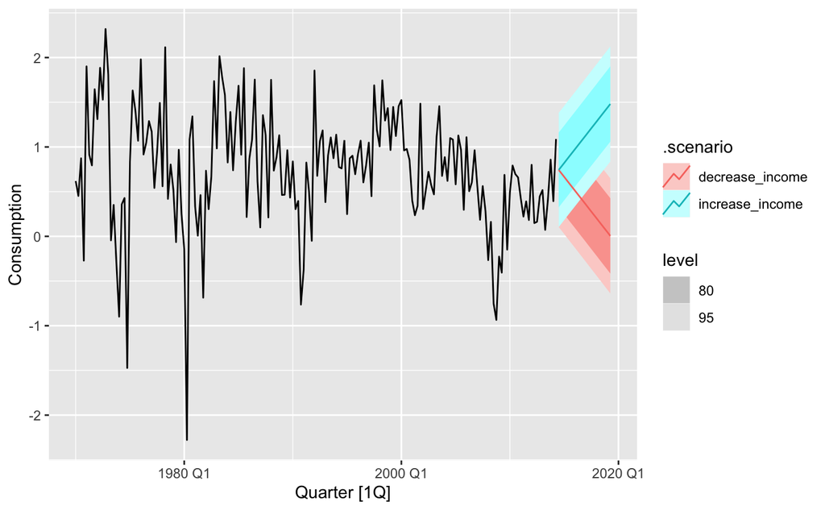

```r
# Future scenarios
future_scenarios <- scenarios( # Create future scenarios
  increase_income = new_data( # Create new data
    us_prediction,  # Original data
    nrow(us_actual) # Number of new data
  ) %>%
    mutate(
      Income = mean(us_prediction$Income) + # Add to mean Income
        seq(0, 1, length = nrow(us_actual)), # Increase from 0 to 1
      # with a length equal to the number of actual data
      Production = mean(us_prediction$Production) +
        rep(0, nrow(us_actual)), # No increase/decrease
      # Repeat 0 with a length equal to the number of actual data
      Savings = mean(us_prediction$Savings) +
        rep(0, nrow(us_actual)),
      Unemployment = mean(us_prediction$Unemployment) +
        rep(0, nrow(us_actual))
    ),
  decrease_income = new_data(
    us_prediction, nrow(us_actual)
  ) %>%
    mutate(
      Income = mean(us_prediction$Income) +
        seq(0, -1, length = nrow(us_actual)),
      Production = mean(us_prediction$Production) +
        rep(0, nrow(us_actual)),
      Savings = mean(us_prediction$Savings) +
        rep(0, nrow(us_actual)),
      Unemployment = mean(us_prediction$Unemployment) +
        rep(0, nrow(us_actual))
    )
)
# Forecast
fc_us <- fit_us_lm %>%
  forecast(new_data = future_scenarios)

# Plot
autoplot(us_prediction, Consumption) +
  autolayer(fc_us)
```

```r
# Fit linear model with trend
fit_us_trend <- us_prediction %>%
  model(tslm = TSLM(Consumption ~ trend()))

# Report fit
report_fit_trend <- report(fit_us_trend)
```

```
Series: Consumption
Model: TSLM

Residuals:
    Min      1Q  Median      3Q     Max
-3.1258 -0.3403  0.0366  0.3867  1.4053

Coefficients:
              Estimate Std. Error t value Pr(>|t|)
(Intercept)  0.9408053  0.0992577   9.478   <2e-16 ***
trend()     -0.0022103  0.0009618  -2.298   0.0227 *
---
Signif. codes:  0 ‘***’ 0.001 ‘**’ 0.01 ‘*’ 0.05 ‘.’ 0.1 ‘ ’ 1

Residual standard error: 0.6593 on 176 degrees of freedom
Multiple R-squared: 0.02913,    Adjusted R-squared: 0.02362
F-statistic: 5.281 on 1 and 176 DF, p-value: 0.022733
```

## The model presented is a Time Series Linear Model (TSLM) for the “Consumption” series. Let’s break down the components of the output to assess its goodness of fit:

## Residuals:

- Residuals are the differences between the observed and predicted values. Ideally, they should be randomly scattered around zero, showing no patterns. The median value is 0.0366, which is close to 0, indicating that the model’s predictions are close to the actual values in the center of the distribution. The interquartile range (from the 1Q to the 3Q) is from -0.3403 to 0.3867. This suggests that 50% of residuals lie in this range, which seems reasonable. However, the minimum and maximum values show that there might be some outliers in the data or some patterns that the model didn’t capture well.

## Coefficients:

- The intercept is significant (p-value < 2e-16), indicating that the model’s baseline prediction (when the time is 0) is different from 0. The trend() coefficient is negative and significant (p-value = 0.0227). This means there’s a statistically significant negative trend in the Consumption series over time. However, the magnitude of this trend is quite small at -0.0022103.

## Residual Standard Error (RSE):

- The RSE is 0.6593. It measures the typical size of the residuals. The smaller the RSE, the better the model’s fit to the data. In the context of the Consumption series, whether this is good or bad depends on the scale of the Consumption values. If they are generally small, then an RSE of 0.6593 might be relatively large, indicating poor fit.

## R-squared and Adjusted R-squared:

- The Multiple R-squared value is 0.02913, suggesting that only about 2.913% of the variation in Consumption is explained by the time trend. This is quite low. The Adjusted R-squared, which penalizes the model for the number of predictors relative to the number of observations, is 0.02362, which is also very low.

## F-statistic:

- The F-statistic tests the overall significance of the model. In this case, the p-value is 0.022733, which is less than 0.05, indicating that the model with the trend predictor is a better fit than a model with no predictors.

## In summary:

- The model captures a statistically significant negative trend in the Consumption series over time, but this trend is small in magnitude. The low R-squared values indicate that the linear model with just a time trend does not capture much of the variability in the Consumption series. The residuals suggest there might be some patterns or outliers that the model hasn’t captured well.
- Given the above information, while the model captures a slight negative trend, it’s not a particularly good model for the Consumption series as it explains only a small portion of the variance. Depending on the purpose of the analysis, you might want to consider more complex models or additional predictor variables to better capture the underlying patterns in the data.

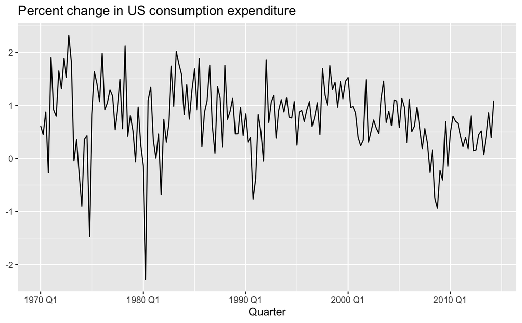

```r
# Plot model
augment(fit_us_trend) %>%
  # Plot quarter on x-axis
  ggplot(aes(x = Quarter)) +
  # Plot actual values
  geom_line(aes(y = Consumption)) +
  labs(
    # No y-axis label
    y = NULL,
    # Change title
    title = "Percent change in US consumption expenditure"
  ) +
  # No title for legend
  guides(colour = guide_legend(title = NULL))
```

```r
# Fit linear model with trend and season
fit_us_season <- us_prediction %>%
  model( # model for time series
    tslm = TSLM( # time series linear model
      Consumption ~ trend() + # trend component
        season() # season component
    )
  )

# Report fit for model with trend and season
report_fit_season <- report(fit_us_season)
```

```
Series: Consumption
Model: TSLM

Residuals:
     Min       1Q   Median       3Q      Max
-3.07488 -0.33612  0.00766  0.41042  1.46950

Coefficients:
                Estimate Std. Error t value Pr(>|t|)
(Intercept)    0.9380208  0.1306974   7.177 2.01e-11 ***
trend()       -0.0021995  0.0009645  -2.281   0.0238 *
season()year2 -0.0485962  0.1393858  -0.349   0.7278
season()year3  0.1186395  0.1401721   0.846   0.3985
season()year4 -0.0615712  0.1401754  -0.439   0.6610
---
Signif. codes:  0 ‘***’ 0.001 ‘**’ 0.01 ‘*’ 0.05 ‘.’ 0.1 ‘ ’ 1

Residual standard error: 0.6611 on 173 degrees of freedom
Multiple R-squared: 0.04045,    Adjusted R-squared: 0.01826
F-statistic: 1.823 on 4 and 173 DF, p-value: 0.12648
```

```r
# Plot model with trend and season
augment(fit_us_season$tslm) %>% # Extracts data from the model
  ggplot(aes(x = Quarter)) +
  # Plot actual values
  geom_line(aes(y = Consumption, color = "Actual")) +
  # Plot fitted values from the model
  geom_line(aes(y = .fitted, color = "Fitted")) +
  labs(
    y = NULL, # No y-axis label
    title = "Percent change in US consumption expenditure with Trend and Season",
    color = "Legend"
  ) +
  scale_color_manual(values = c("Actual" = "black", "Fitted" = "orange")) +
  theme_minimal()
```

[output not shown]

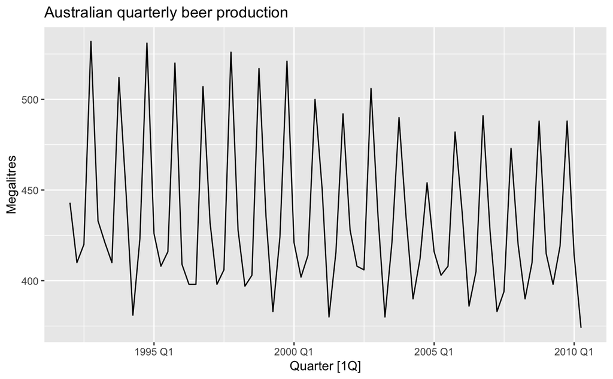

```r
# Australian beer example
data("aus_production")

# Australian beer production
recent_production <- aus_production %>%
  filter(year(Quarter) >= 1992)

# Plot
recent_production %>%
  autoplot(Beer) +
  labs(y = "Megalitres", title = "Australian quarterly beer production")
```

```r
# Fit model with trend and season
fit_beer <- recent_production %>%
  model(tslm = TSLM(Beer ~ trend() + season()))

# Report fit
report_fit_beer <- report(fit_beer)
```

```
Series: Beer
Model: TSLM

Residuals:
     Min       1Q   Median       3Q      Max
-42.9029  -7.5995  -0.4594   7.9908  21.7895

Coefficients:
               Estimate Std. Error t value Pr(>|t|)
(Intercept)   441.80044    3.73353 118.333  < 2e-16 ***
trend()        -0.34027    0.06657  -5.111 2.73e-06 ***
season()year2 -34.65973    3.96832  -8.734 9.10e-13 ***
season()year3 -17.82164    4.02249  -4.430 3.45e-05 ***
season()year4  72.79641    4.02305  18.095  < 2e-16 ***
---
Signif. codes:  0 ‘***’ 0.001 ‘**’ 0.01 ‘*’ 0.05 ‘.’ 0.1 ‘ ’ 1

Residual standard error: 12.23 on 69 degrees of freedom
Multiple R-squared: 0.9243, Adjusted R-squared: 0.9199
F-statistic: 210.7 on 4 and 69 DF, p-value: < 2.22e-16
```

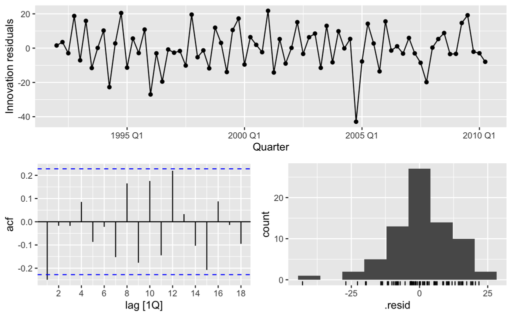

```r
# Plot residuals
fit_beer %>%
  gg_tsresiduals()
```

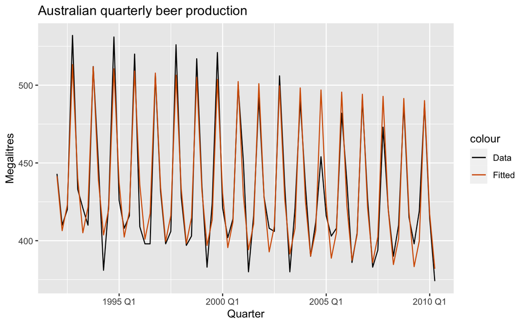

```r
# Plot fitted model
augment(fit_beer) %>%
  ggplot(aes(x = Quarter)) +
  geom_line(aes(y = Beer, colour = "Data")) +
  geom_line(aes(y = .fitted, colour = "Fitted")) +
  labs(y="Megalitres",title ="Australian quarterly beer production") +
  scale_colour_manual(values = c(Data = "black", Fitted = "#D55E00"))
```

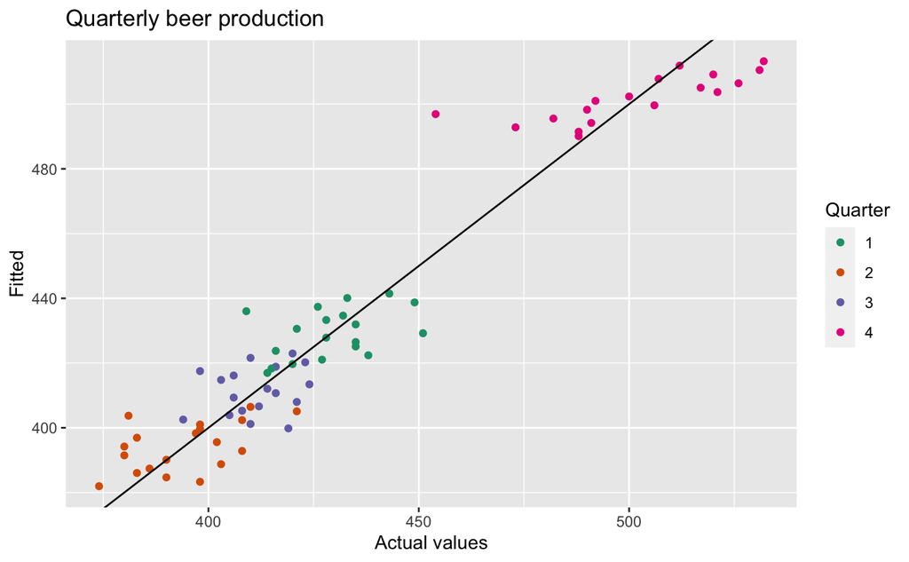

```r
# Examining seasonality
augment(fit_beer) %>%
  ggplot(aes(x=Beer, y=.fitted, colour=factor(quarter(Quarter)))) +
  geom_point() +
  labs(y="Fitted", x="Actual values", title = "Quarterly beer production") +
  scale_colour_brewer(palette="Dark2", name="Quarter") +
  geom_abline(intercept=0, slope=1)
```

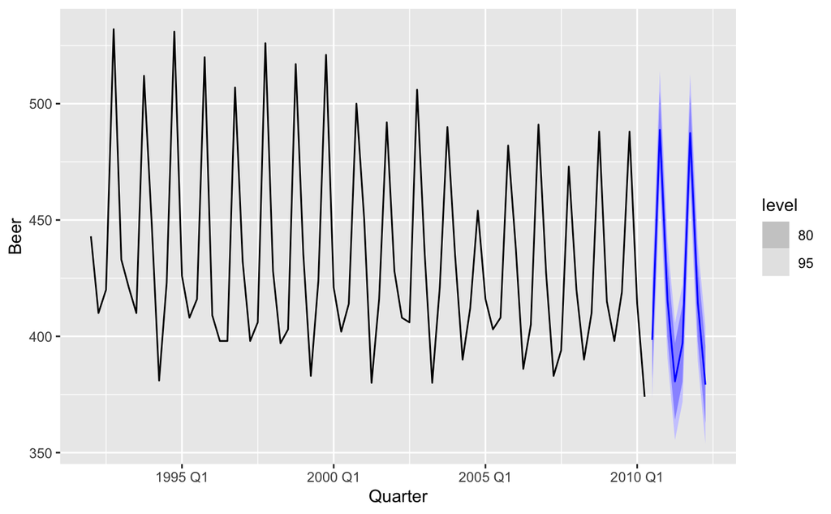

```r
# Forecasting prediction
fc <- fit_beer %>% forecast

# Plot forecast
fc %>% autoplot(recent_production)
```